# DSA6100: Final Project (Winter 2021)

Md Reza, Christopher Kujawa

April 26, 2021

*Load the required packages*

```r
library(dplyr) # for data manipulation
library(stringr) # for data manipulation
library(caret) # for sampling
```

```r
library(caTools) # for train/test split
library(ggplot2) # for data visualization
library(corrplot) # for correlations
library(Rtsne) # for tsne plotting
library(DMwR) # for smote implementation
library(ROSE)# for ROSE sampling
library(rpart)# for decision tree model
library(Rborist)# for random forest model
library(xgboost) # for xgboost model
library(randomForest) # for Random Forest
library(e1071) # for SVM
library(jsonlite) # for reading JSON file
library(neuralnet) # for building neuralnet model
library(grid)
library(data.table) # for enhancing data frame
suppressMessages(library(DataExplorer))
suppressMessages(library(reshape2))
suppressMessages(library("gridExtra"))
```

#Set the work directory and read the data

```r
setwd("C:\\Users\\mreza6\\Documents\\MD_Docs\\WSU\\Winter 2021\\R\\Final Project")
df_cc <- read.csv("creditcard.csv")
```

# Data Exploration

*Get the columns & rows count*

```r
dim(df_cc)
```

```
## [1] 284807     31
```

*Get the column’s name*

```r
names(df_cc)
```

```
##  [1] "Time"   "V1"     "V2"     "V3"     "V4"     "V5"     "V6"     "V7"
##  [9] "V8"     "V9"     "V10"    "V11"    "V12"    "V13"    "V14"    "V15"
## [17] "V16"    "V17"    "V18"    "V19"    "V20"    "V21"    "V22"    "V23"
## [25] "V24"    "V25"    "V26"    "V27"    "V28"    "Amount" "Class"
```

*Get the top 5 rows*

```r
head(df_cc,5)
```

```
##   Time         V1          V2        V3         V4          V5          V6
## 1    0 -1.3598071 -0.07278117 2.5363467  1.3781552 -0.33832077  0.46238778
## 2    0  1.1918571  0.26615071 0.1664801  0.4481541  0.06001765 -0.08236081
## 3    1 -1.3583541 -1.34016307 1.7732093  0.3797796 -0.50319813  1.80049938
## 4    1 -0.9662717 -0.18522601 1.7929933 -0.8632913 -0.01030888  1.24720317
## 5    2 -1.1582331  0.87773675 1.5487178  0.4030339 -0.40719338  0.09592146
##            V7          V8         V9         V10        V11         V12
## 1  0.23959855  0.09869790  0.3637870  0.09079417 -0.5515995 -0.61780086
## 2 -0.07880298  0.08510165 -0.2554251 -0.16697441  1.6127267  1.06523531
## 3  0.79146096  0.24767579 -1.5146543  0.20764287  0.6245015  0.06608369
## 4  0.23760894  0.37743587 -1.3870241 -0.05495192 -0.2264873  0.17822823
## 5  0.59294075 -0.27053268  0.8177393  0.75307443 -0.8228429  0.53819555
##          V13        V14        V15        V16        V17         V18        V19
## 1 -0.9913898 -0.3111694  1.4681770 -0.4704005  0.2079712  0.02579058  0.4039930
## 2  0.4890950 -0.1437723  0.6355581  0.4639170 -0.1148047 -0.18336127 -0.1457830
## 3  0.7172927 -0.1659459  2.3458649 -2.8900832  1.1099694 -0.12135931 -2.2618571
## 4  0.5077569 -0.2879237 -0.6314181 -1.0596472 -0.6840928  1.96577500 -1.2326220
## 5  1.3458516 -1.1196698  0.1751211 -0.4514492 -0.2370332 -0.03819479  0.8034869
##           V20          V21          V22        V23         V24        V25
## 1  0.25141210 -0.018306778  0.277837576 -0.1104739  0.06692807  0.1285394
## 2 -0.06908314 -0.225775248 -0.638671953  0.1012880 -0.33984648  0.1671704
## 3  0.52497973  0.247998153  0.771679402  0.9094123 -0.68928096 -0.3276418
## 4 -0.20803778 -0.108300452  0.005273597 -0.1903205 -1.17557533  0.6473760
## 5  0.40854236 -0.009430697  0.798278495 -0.1374581  0.14126698 -0.2060096
##          V26          V27         V28 Amount Class
## 1 -0.1891148  0.133558377 -0.02105305 149.62     0
## 2  0.1258945 -0.008983099  0.01472417   2.69     0
## 3 -0.1390966 -0.055352794 -0.05975184 378.66     0
## 4 -0.2219288  0.062722849  0.06145763 123.50     0
## 5  0.5022922  0.219422230  0.21515315  69.99     0
```

*Check the class imbalance*

```r
table(df_cc$Class)
```

```
##
##      0      1
## 284315    492
```

```r
prop.table(table(df_cc$Class))
```

```
##
##           0           1
## 0.998272514 0.001727486
```

*Get the variance and standard deviation of credit card fraud amount*

```r
var(df_cc$Amount)
```

```
## [1] 62560.07
```

```r
sd(df_cc$Amount)
```

```
## [1] 250.1201
```

*Get the summary of credit card fraud data*

```r
summary(df_cc$Amount)
```

```
##     Min.  1st Qu.   Median     Mean  3rd Qu.     Max.
##     0.00     5.60    22.00    88.35    77.17 25691.16
```

# Data Preparation

##### Handling missing values

*Look for missing values*

```r
introduce(df_cc)
```

```
##     rows columns discrete_columns continuous_columns all_missing_columns
## 1 284807      31                0                 31                   0
##   total_missing_values complete_rows total_observations memory_usage
## 1                    0        284807            8829017     69499584
```

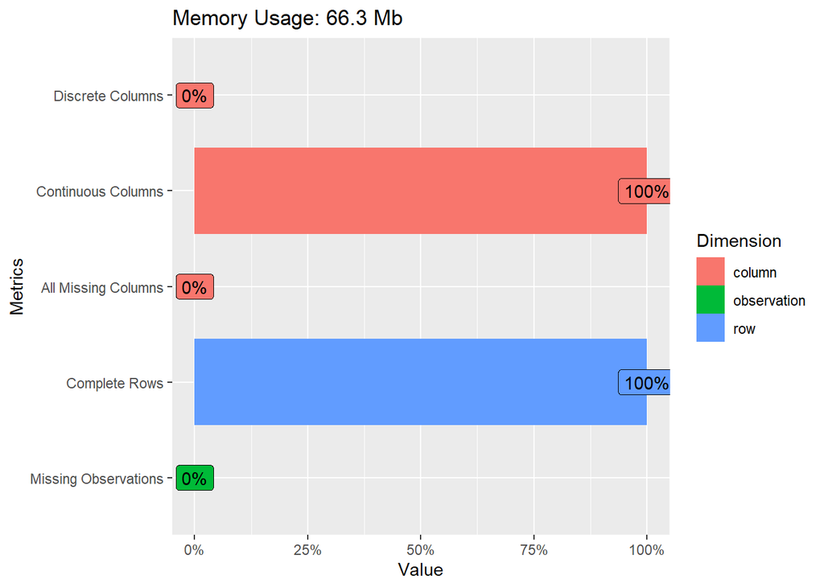

```r
plot_intro(df_cc)
```

*Determined if there any other missing values*

```r
for (Var in names(df_cc)) {
    missing <- sum(is.na(df_cc[,Var]))
    if (missing > 0) {
        print(c(Var,missing))
    }
}
```

*Remove NULL values*

```r
data=na.omit((data))
```

# Data Transformation

*Using scale() function scale the Amount variable*

```r
df_cc$Amount=scale(df_cc$Amount)
df_scaled=df_cc[,-c(1)]
head(df_scaled)
```

```
##           V1          V2        V3         V4          V5          V6
## 1 -1.3598071 -0.07278117 2.5363467  1.3781552 -0.33832077  0.46238778
## 2  1.1918571  0.26615071 0.1664801  0.4481541  0.06001765 -0.08236081
## 3 -1.3583541 -1.34016307 1.7732093  0.3797796 -0.50319813  1.80049938
## 4 -0.9662717 -0.18522601 1.7929933 -0.8632913 -0.01030888  1.24720317
## 5 -1.1582331  0.87773675 1.5487178  0.4030339 -0.40719338  0.09592146
## 6 -0.4259659  0.96052304 1.1411093 -0.1682521  0.42098688 -0.02972755
##            V7          V8         V9         V10        V11         V12
## 1  0.23959855  0.09869790  0.3637870  0.09079417 -0.5515995 -0.61780086
## 2 -0.07880298  0.08510165 -0.2554251 -0.16697441  1.6127267  1.06523531
## 3  0.79146096  0.24767579 -1.5146543  0.20764287  0.6245015  0.06608369
## 4  0.23760894  0.37743587 -1.3870241 -0.05495192 -0.2264873  0.17822823
## 5  0.59294075 -0.27053268  0.8177393  0.75307443 -0.8228429  0.53819555
## 6  0.47620095  0.26031433 -0.5686714 -0.37140720  1.3412620  0.35989384
##          V13        V14        V15        V16         V17         V18
```

[output cut: 20 more lines]

##### Creating factor for Data Visualization

```r
df_cc_viz <- df_cc %>%
     mutate(Class = as.factor(Class))
levels(df_cc_viz$Class) <- c('Genuine', 'Fraud')
table(df_cc_viz$Class)
```

```
##
## Genuine   Fraud
##  284315     492
```

##### Creating factor for Data Modeling

```r
df_cc$Class <- as.factor(df_cc$Class)
glimpse(df_cc)
```

```
## Rows: 284,807
## Columns: 31
## $ Time   <dbl> 0, 0, 1, 1, 2, 2, 4, 7, 7, 9, 10, 10, 10, 11, 12, 12, 12, 13, 1~
## $ V1     <dbl> -1.3598071, 1.1918571, -1.3583541, -0.9662717, -1.1582331, -0.4~
## $ V2     <dbl> -0.07278117, 0.26615071, -1.34016307, -0.18522601, 0.87773675, ~
## $ V3     <dbl> 2.53634674, 0.16648011, 1.77320934, 1.79299334, 1.54871785, 1.1~
## $ V4     <dbl> 1.37815522, 0.44815408, 0.37977959, -0.86329128, 0.40303393, -0~
## $ V5     <dbl> -0.33832077, 0.06001765, -0.50319813, -0.01030888, -0.40719338,~
## $ V6     <dbl> 0.46238778, -0.08236081, 1.80049938, 1.24720317, 0.09592146, -0~
## $ V7     <dbl> 0.239598554, -0.078802983, 0.791460956, 0.237608940, 0.59294074~
## $ V8     <dbl> 0.098697901, 0.085101655, 0.247675787, 0.377435875, -0.27053267~
## $ V9     <dbl> 0.3637870, -0.2554251, -1.5146543, -1.3870241, 0.8177393, -0.56~
## $ V10    <dbl> 0.09079417, -0.16697441, 0.20764287, -0.05495192, 0.75307443, -~
## $ V11    <dbl> -0.55159953, 1.61272666, 0.62450146, -0.22648726, -0.82284288, ~
## $ V12    <dbl> -0.61780086, 1.06523531, 0.06608369, 0.17822823, 0.53819555, 0.~
```

[output cut: 18 more lines]

*visualize the factored class attributes*

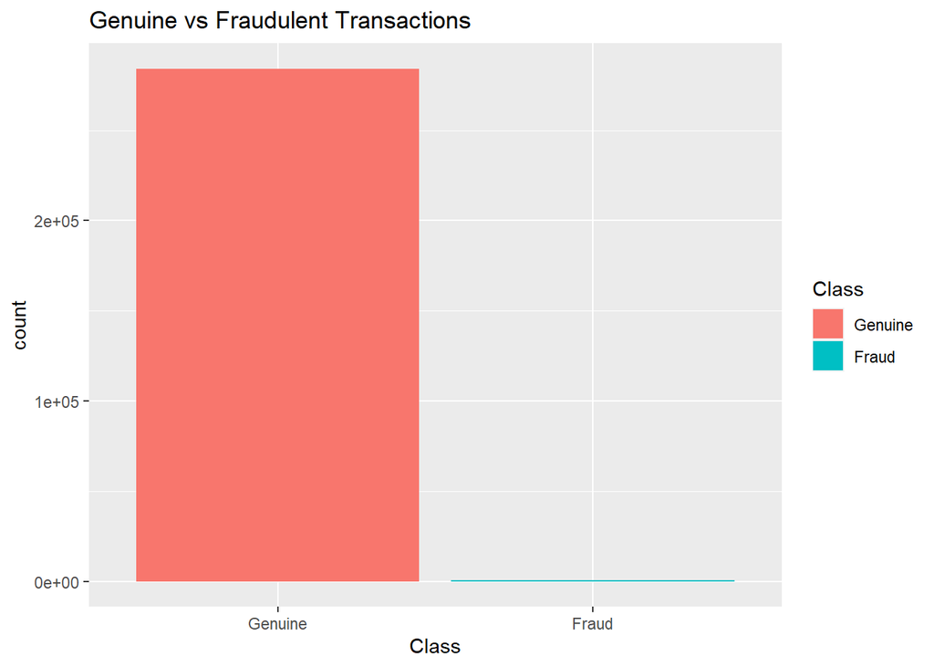

```r
ggplot(df_cc_viz)+
     geom_bar(aes(x = Class, fill = Class))+ggtitle("Genuine vs Fraudulent Transactions")
```

##### Under sampling and split datasets based on target variable “Class”

*To avoid possible risk with the loss of information (that includes using 492 fraudulent transactions with 284,315 non-fraudulent transactions) this data set is broken down based on the target variable “Class.” We also created a new data dataset with a limited number of fraudulent and genuine transactions so that we will have a consistency between the fraudulent and genuine transactions’ ratio and that would also improve the models’ accuracy as well.*

```r
fraud_class <- df_cc %>%
  filter(Class == 1)
split <- sample(1:nrow(fraud_class), 350)
fraud_class_new <- fraud_class[split,]
genuine_class <- df_cc %>%
  filter(Class == 0)
random <- sample(1:nrow(genuine_class),984)
genuine_class <- genuine_class[random,]
genuine_class_new <- genuine_class[1:700,]
```

##### Combing both of the data to get one data to work with

```r
df_cc_new <- rbind(fraud_class_new, genuine_class_new)
df_cc_new <- df_cc_new[sample(1:nrow(df_cc_new)),]
```

*Create two different datasets with $Genuine & $Fraud class*

```r
fraud_Data <- subset(df_cc_viz,Class=='Fraud')
real_Data <- subset(df_cc_viz,Class=='Genuine')
```

# Data Visualization

*Explore if fraudulent transaction occur on a specific time of a day*

```r
df_cc_viz_new<-na.omit(read.csv("creditcard.csv"))
df_cc_viz_new$night_trans <- as.factor((floor(df_cc_viz_new$Time/60/60)%%24 <= 9)*1)
```

*Split the fraudulent and genuine transaction by night and day*

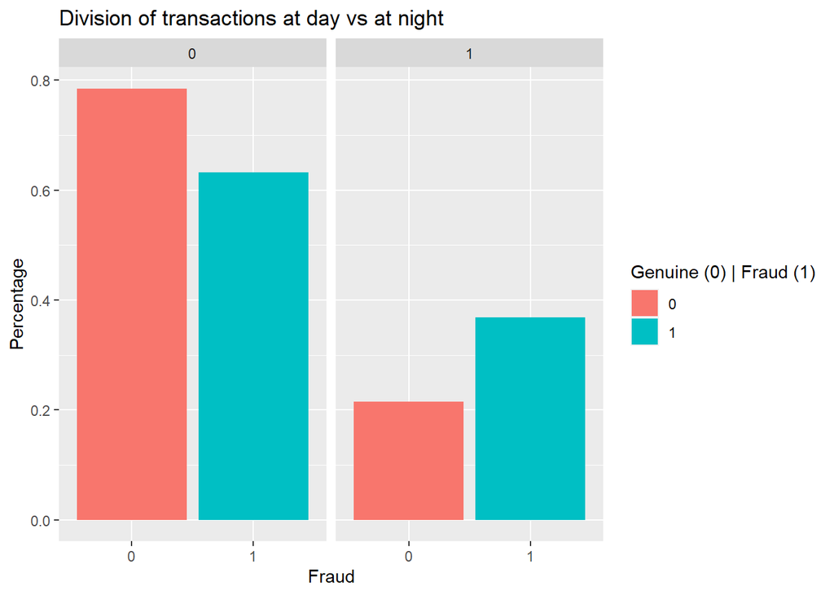

```r
toPlot <- df_cc_viz_new
toPlot$factClass <- as.factor(df_cc_viz_new$Class)
toPlot <- table(toPlot$night_trans, toPlot$factClass)
toPlot <- melt(toPlot)
toPlot$value[toPlot$Var2==0] = toPlot$value[toPlot$Var2==0]/sum(toPlot$value[toPlot$Var2==0])
toPlot$value[toPlot$Var2==1] = toPlot$value[toPlot$Var2==1]/sum(toPlot$value[toPlot$Var2==1])
names(toPlot) <- c("IsNight", "Fraud", "Percentage")
toPlot$Fraud <-as.factor(toPlot$Fraud)
ggplot(toPlot, aes(x=Fraud, y=Percentage, fill=Fraud))+geom_bar(stat="identity")+
  facet_grid(~IsNight)+
  ggtitle("Division of transactions at day vs at night")+
  scale_fill_discrete(name="Genuine (0) | Fraud (1)")
```

*During the daytime the ratio of Genuine transactions is higher compare to fraudulent transactions .*

*While during the night time the ratio of Fraudulent transactions is higher compare to Genuine transactions .*

##### Cumulative % graphs for Genuine and Fraud transaction amounts

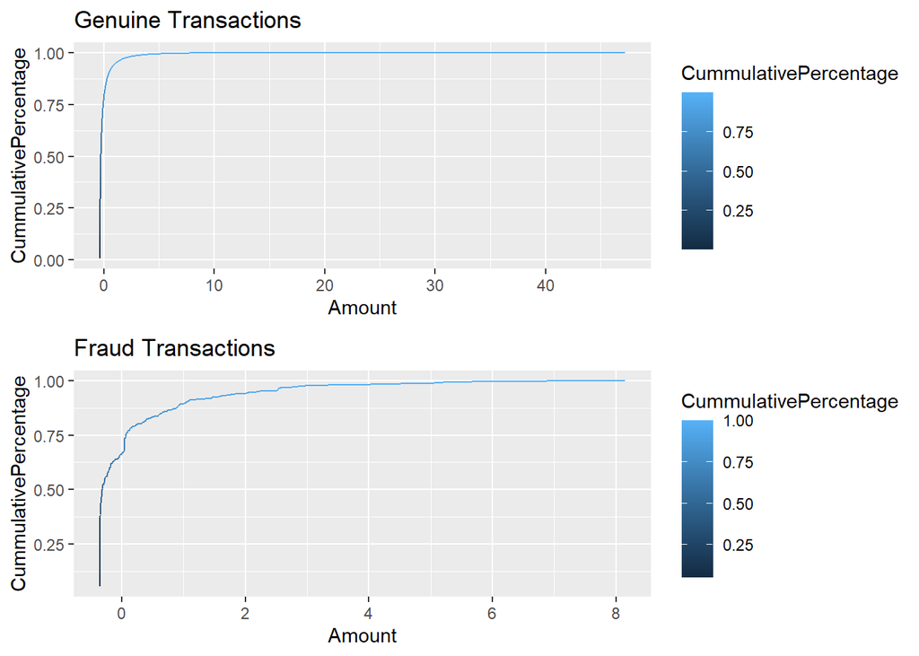

```r
tab <- melt(table(df_cc_viz$Amount[df_cc_viz$Class=='Genuine']))
tab$CummulativePercentage <- cumsum(tab$value) / sum(tab$value) # cumulative Frequency
names(tab)[1] <- "Amount"
p5 <- ggplot(tab[tab$Amount<50,], aes(x=Amount, y=CummulativePercentage, color=CummulativePercentage))+
  geom_line()+ggtitle("Genuine Transactions")

tab <- melt(table(df_cc_viz$Amount[df_cc_viz$Class=='Fraud']))
tab$CummulativePercentage <- cumsum(tab$value) / sum(tab$value)
names(tab)[1] <- "Amount"
p6 <- ggplot(tab[tab$Amount<50,], aes(x=Amount, y=CummulativePercentage, color=CummulativePercentage))+
  geom_line()+ggtitle("Fraud Transactions")

grid.arrange(p5, p6)
```

*The cumulative frequency in the above histogram seems to have no anomaly at all. So, it is safe to say that the transaction under the amount variable does not have any anomaly.*

##### Exploring if Fraud Transactions are related with amount and time of transaction?

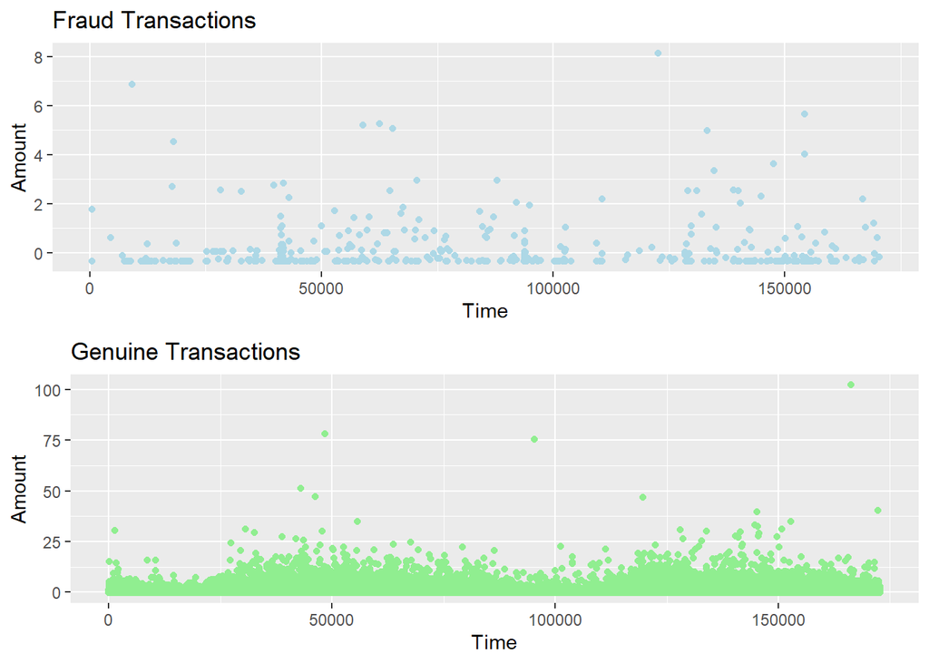

```r
p7<-ggplot(fraud_Data, aes(x=Time, y=Amount)) +
  geom_point(colour="light blue") + ggtitle("Fraud Transactions")

p8<-ggplot(real_Data, aes(x=Time, y=Amount)) +
  geom_point(colour="light green")+ggtitle("Genuine Transactions")

grid.arrange(p7, p8)
```

*Again, we do not see particular anomaly between fraud and Genuine transactions.

##### Comparison of mean by Fraudulent and Genuine transactions

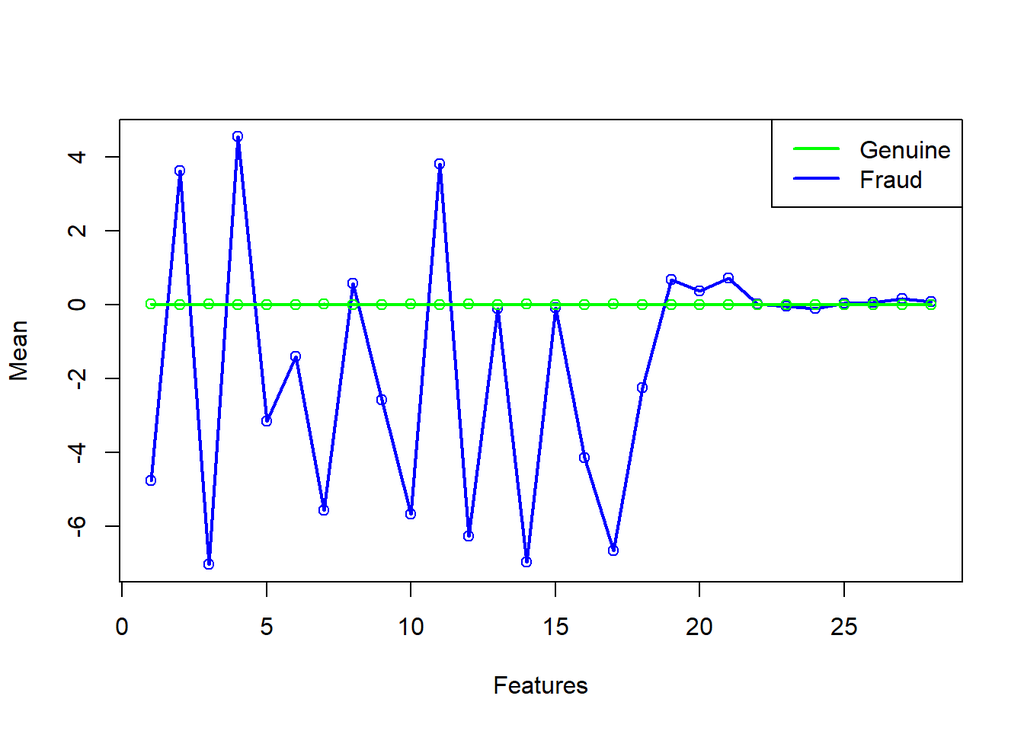

```r
skew <- sum(as.numeric(df_cc_viz$Class))/nrow(df_cc_viz)
mugood <- apply(real_Data[sample(rownames(real_Data), size = as.integer(skew *nrow(df_cc_viz)), replace = T), -c(1, 30, 31)], 2, mean)
muanom <- apply(fraud_Data[, -c(1, 30, 31)], 2, mean)
plot(muanom, col = "blue", xlab = "Features", ylab = "Mean")
lines(muanom, col = "blue", lwd = 2)
points(mugood, col = "green")
lines(mugood, col = "green", lwd = 2)
legend("topright", legend = c("Genuine", "Fraud"), lty = c(1,1), col = c("green", "blue"), lwd = c(2,2))
```

*From the above chart, we could notice that the mean of fraud transactions is different from the genuine one. The fraudulent transactions have higher fluctuation while the genuine transactions have a normal pattern.*

##### Before get in to details first look in to the each variables

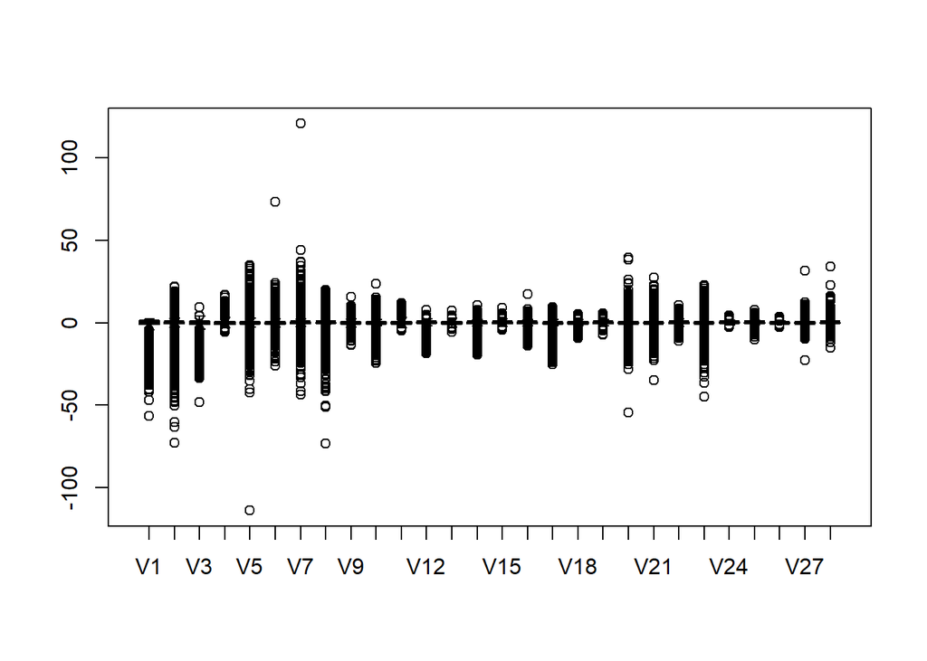

```r
boxplot(df_cc_viz[2:29])
```

*Notice some of the features (i.e. V13, V19, V24) in the above boxplot are symmetrical, Though it seems we have some outliers, but they might not be a problem since they are very few in number.*

```r
common_theme <- theme(plot.title = element_text(hjust = 0.5, face = "bold"))
```

*Correlation Map*

*Making a correlation matrix using basic COR function.*

```r
corr_data <- df_cc
corr_data$Class <- as.integer(corr_data$Class)
corr_matrix <- round(cor(corr_data),2)
head(corr_matrix)
```

```
##       Time   V1    V2    V3    V4   V5    V6   V7    V8    V9  V10   V11  V12
## Time  1.00 0.12 -0.01 -0.42 -0.11 0.17 -0.06 0.08 -0.04 -0.01 0.03 -0.25 0.12
## V1    0.12 1.00  0.00  0.00  0.00 0.00  0.00 0.00  0.00  0.00 0.00  0.00 0.00
## V2   -0.01 0.00  1.00  0.00  0.00 0.00  0.00 0.00  0.00  0.00 0.00  0.00 0.00
## V3   -0.42 0.00  0.00  1.00  0.00 0.00  0.00 0.00  0.00  0.00 0.00  0.00 0.00
## V4   -0.11 0.00  0.00  0.00  1.00 0.00  0.00 0.00  0.00  0.00 0.00  0.00 0.00
## V5    0.17 0.00  0.00  0.00  0.00 1.00  0.00 0.00  0.00  0.00 0.00  0.00 0.00
##        V13  V14   V15  V16   V17  V18  V19   V20  V21  V22  V23   V24   V25
## Time -0.07 -0.1 -0.18 0.01 -0.07 0.09 0.03 -0.05 0.04 0.14 0.05 -0.02 -0.23
## V1    0.00  0.0  0.00 0.00  0.00 0.00 0.00  0.00 0.00 0.00 0.00  0.00  0.00
## V2    0.00  0.0  0.00 0.00  0.00 0.00 0.00  0.00 0.00 0.00 0.00  0.00  0.00
## V3    0.00  0.0  0.00 0.00  0.00 0.00 0.00  0.00 0.00 0.00 0.00  0.00  0.00
## V4    0.00  0.0  0.00 0.00  0.00 0.00 0.00  0.00 0.00 0.00 0.00  0.00  0.00
## V5    0.00  0.0  0.00 0.00  0.00 0.00 0.00  0.00 0.00 0.00 0.00  0.00  0.00
##        V26   V27   V28 Amount Class
## Time -0.04 -0.01 -0.01  -0.01 -0.01
## V1    0.00  0.00  0.00  -0.23 -0.10
## V2    0.00  0.00  0.00  -0.53  0.09
## V3    0.00  0.00  0.00  -0.21 -0.19
## V4    0.00  0.00  0.00   0.10  0.13
## V5    0.00  0.00  0.00  -0.39 -0.09
```

*Melting values using melt function*

```r
melted_corr_matrix <- melt(corr_matrix)
head(melted_corr_matrix)
```

```
##   Var1 Var2 value
## 1 Time Time  1.00
## 2   V1 Time  0.12
## 3   V2 Time -0.01
## 4   V3 Time -0.42
## 5   V4 Time -0.11
## 6   V5 Time  0.17
```

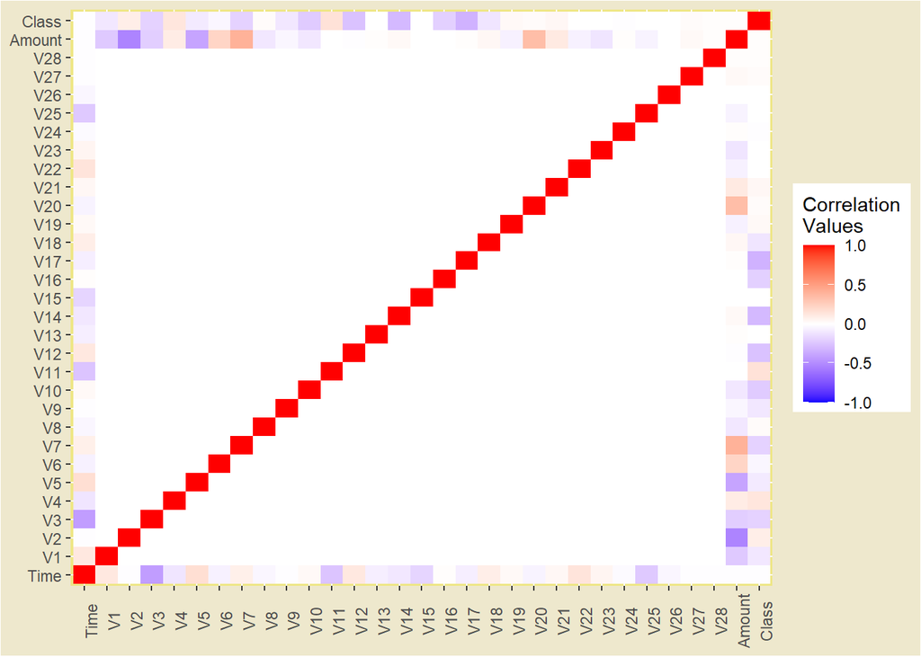

```r
correlation_plot <- ggplot(data = melted_corr_matrix) +
  geom_tile(aes(Var1,Var2, fill=value))+
  theme(plot.background = element_rect("cornsilk2"),
        panel.background = element_rect("khaki2"),
        axis.text.x = element_text(angle = 90),
        axis.title = element_blank())+
  scale_fill_gradient2(low = "blue", high = "red", name = "Correlation\nValues", limit = c(-1,1))

correlation_plot
```

*In the above correlation plot, we could observe that though the Time and Amount variables have some correlations with PCA transformed features (that includes V1 - V28), but the Time and Amount do not have any correlation at all. We also noticed that none of the PCA transformed (V1-V28) have any correlation, which justifies the non-linearity as well.*

*Distribution of Time attrib by Class*

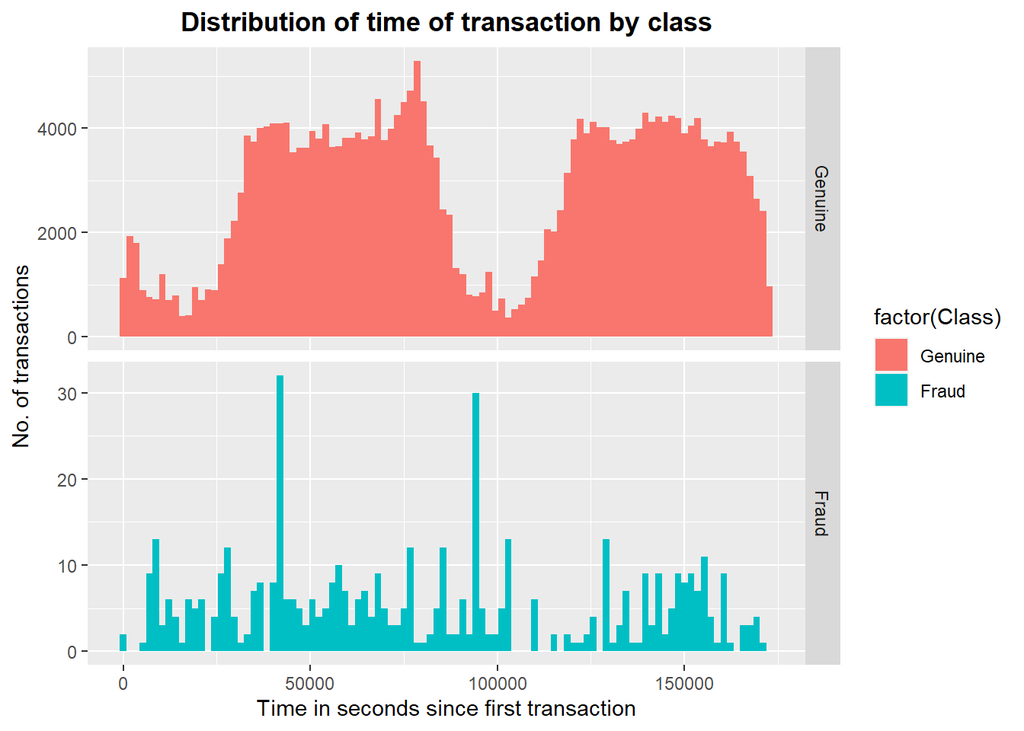

```r
df_cc_viz %>%
  ggplot(aes(x = Time, fill = factor(Class))) + geom_histogram(bins = 100)+
  labs(x = 'Time in seconds since first transaction', y = 'No. of transactions') +
  ggtitle('Distribution of time of transaction by class') +
  facet_grid(Class ~ ., scales = 'free_y') + common_theme
```

*Distribution of variable ‘Amount’ by class*

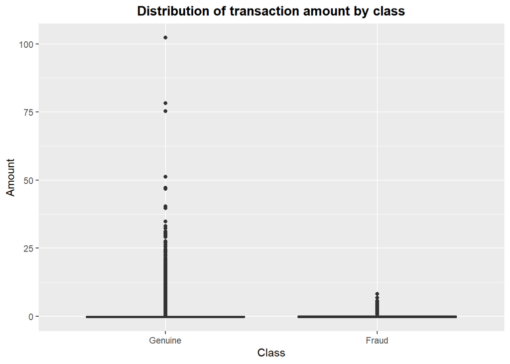

```r
ggplot(df_cc_viz, aes(x = factor(Class), y = Amount)) + geom_boxplot() +
  labs(x = 'Class', y = 'Amount') +
  ggtitle("Distribution of transaction amount by class") + common_theme
```

# Building the Data Model with GLM, Random Forest, KNN, Naive Bayes, and SVM

##### Train - Same as df_cc_new

```r
train <- df_cc_new
table(train$Class)
```

```
##
##   0   1
## 700 350
```

##### Create the Test dataset

```r
test_class1 <- fraud_class[-split,]
test_class2 <- genuine_class[701:984,]

test <- rbind(test_class1, test_class2)
table(test$Class)
```

```
##
##   0   1
## 284 142
```

# Logistic Regression Model

*Run the model with test dataset*

```r
glm.fit <- train(Class~.,data = train, method = "glm", family = "binomial",
                   trControl = trainControl(method = "repeatedcv", number = 5, repeats = 10))
glm.fit.pred <- predict(glm.fit, test[,-31])
glm.fit.conf.matrix <- confusionMatrix(test$Class, glm.fit.pred, mode = "everything", positive = "1")
glm.fit.conf.matrix
```

```
## Confusion Matrix and Statistics
##
##           Reference
## Prediction   0   1
##          0 274  10
##          1  22 120
##
##                Accuracy : 0.9249
##                  95% CI : (0.8956, 0.9481)
##     No Information Rate : 0.6948
##     P-Value [Acc > NIR] : < 2e-16
##
##                   Kappa : 0.8273
##
##  Mcnemar's Test P-Value : 0.05183
##
##             Sensitivity : 0.9231
##             Specificity : 0.9257
##          Pos Pred Value : 0.8451
##          Neg Pred Value : 0.9648
##               Precision : 0.8451
##                  Recall : 0.9231
##                      F1 : 0.8824
##              Prevalence : 0.3052
##          Detection Rate : 0.2817
##    Detection Prevalence : 0.3333
##       Balanced Accuracy : 0.9244
##
##        'Positive' Class : 1
##
```

*ROC curve to find the area under the curve (AUC) for test dataset*

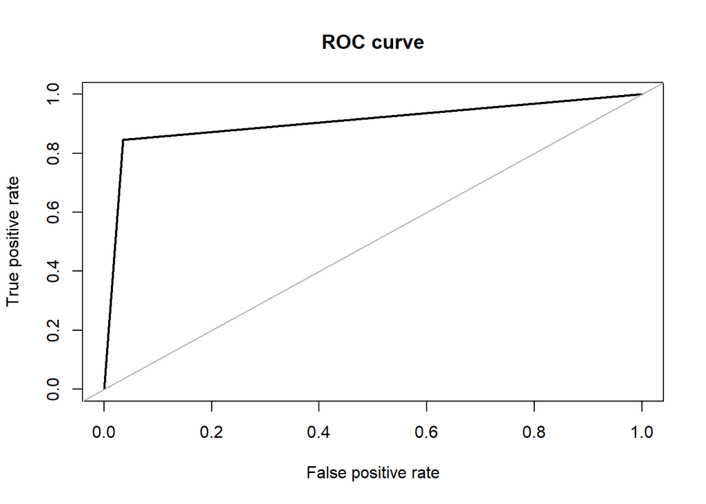

```
## Area under the curve (AUC): 0.905
```

```r
roc.curve(test$Class, glm.fit.pred, plotit = TRUE)
```

*Run the model with whole dataset*

```r
glm.fit.pred.all <- predict(glm.fit, df_cc[,-31])
glm.fit.conf.matrix.all <- confusionMatrix(df_cc$Class, glm.fit.pred.all, mode = "everything", positive = "1")
glm.fit.conf.matrix.all
```

```
## Confusion Matrix and Statistics
##
##           Reference
## Prediction      0      1
##          0 279756   4559
##          1     77    415
##
##                Accuracy : 0.9837
##                  95% CI : (0.9833, 0.9842)
##     No Information Rate : 0.9825
##     P-Value [Acc > NIR] : 5.287e-07
##
##                   Kappa : 0.1492
##
##  Mcnemar's Test P-Value : < 2.2e-16
##
##             Sensitivity : 0.083434
##             Specificity : 0.999725
##          Pos Pred Value : 0.843496
##          Neg Pred Value : 0.983965
##               Precision : 0.843496
##                  Recall : 0.083434
##                      F1 : 0.151848
##              Prevalence : 0.017464
##          Detection Rate : 0.001457
##    Detection Prevalence : 0.001727
##       Balanced Accuracy : 0.541579
##
##        'Positive' Class : 1
##
```

*ROC curve to find the area under the curve (AUC) for whole dataset*

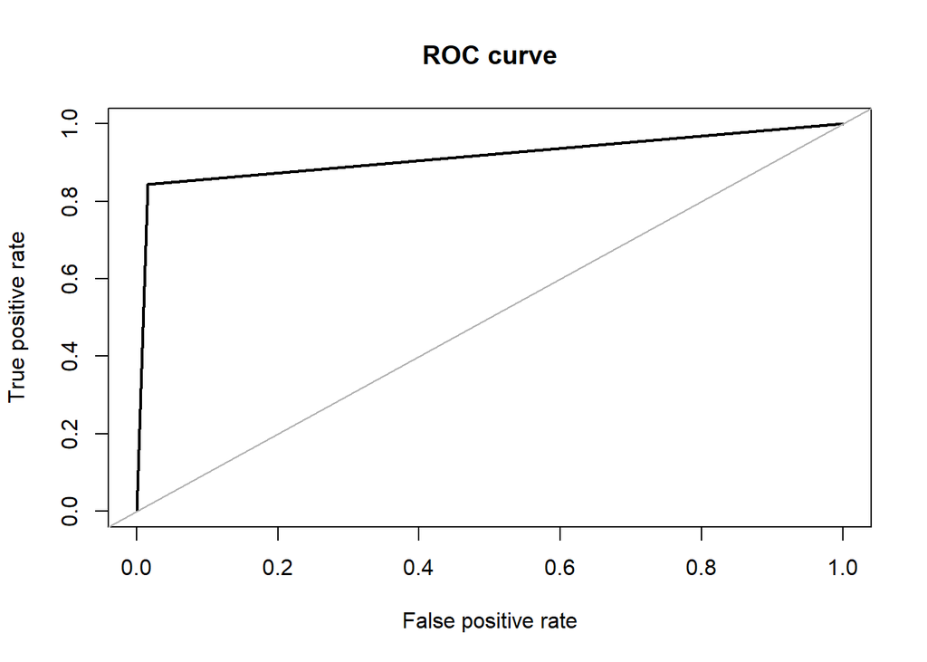

```
## Area under the curve (AUC): 0.914
```

```r
roc.curve(df_cc$Class, glm.fit.pred.all, plotit = TRUE)
```

# Random Forest

*Run the model with test dataset*

```r
set.seed(421)
rf.model <- randomForest(Class~., train, importance = T, nPerm = 4, type = "classification", ntree = 775, mtry = 1)
rf.pred <- predict(rf.model, test[,-31], type = "class")
rf.conf.matrix <- confusionMatrix(test$Class, rf.pred, mode = "everything", positive = "1")
rf.conf.matrix
```

```
## Confusion Matrix and Statistics
##
##           Reference
## Prediction   0   1
##          0 280   4
##          1  19 123
##
##                Accuracy : 0.946
##                  95% CI : (0.9201, 0.9655)
##     No Information Rate : 0.7019
##     P-Value [Acc > NIR] : < 2.2e-16
##
##                   Kappa : 0.8752
##
##  Mcnemar's Test P-Value : 0.003509
##
##             Sensitivity : 0.9685
##             Specificity : 0.9365
##          Pos Pred Value : 0.8662
##          Neg Pred Value : 0.9859
##               Precision : 0.8662
##                  Recall : 0.9685
##                      F1 : 0.9145
##              Prevalence : 0.2981
##          Detection Rate : 0.2887
##    Detection Prevalence : 0.3333
##       Balanced Accuracy : 0.9525
##
##        'Positive' Class : 1
##
```

*ROC curve to find the area under the curve (AUC) for test dataset*

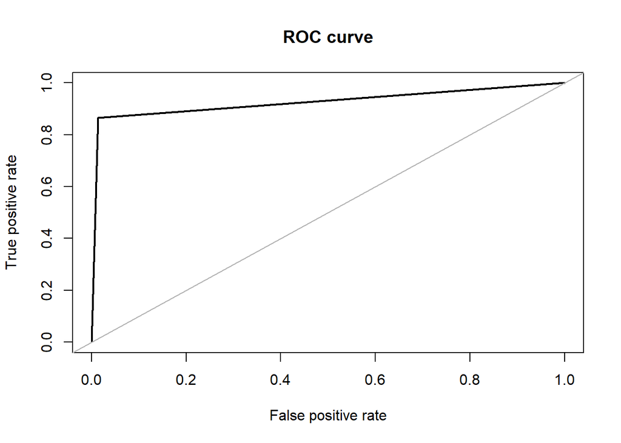

```
## Area under the curve (AUC): 0.926
```

```r
roc.curve(test$Class, rf.pred, plotit = TRUE)
```

*Run the model with whole dataset*

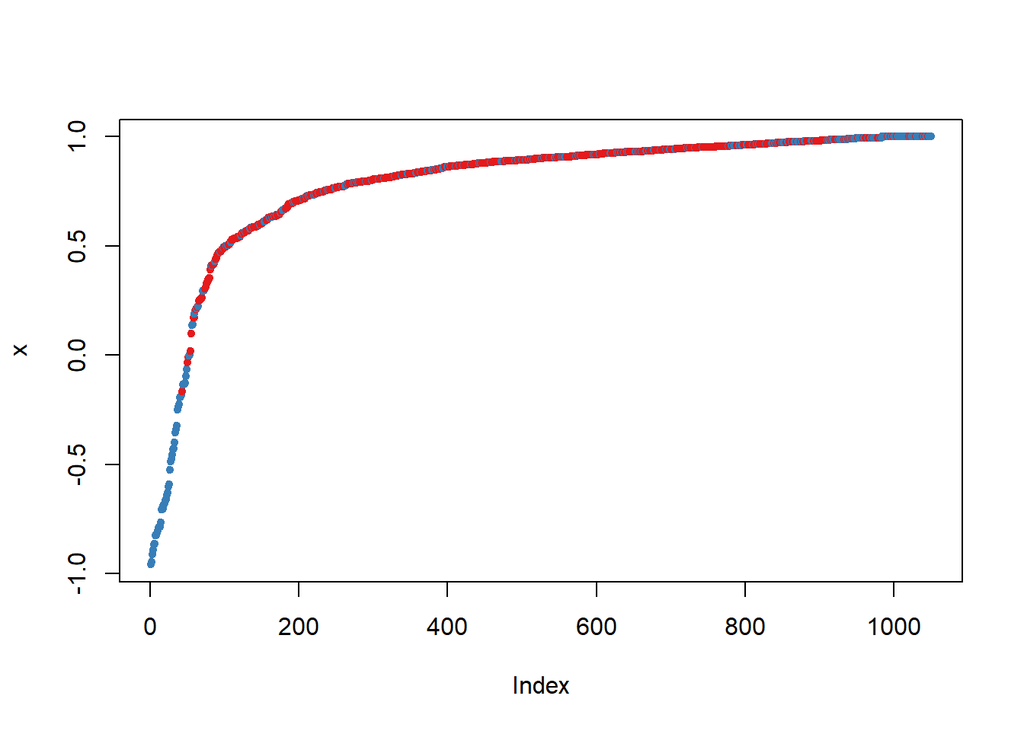

```r
plot(margin(rf.model,test$Class))
```

```r
rf.pred.all <- predict(rf.model, df_cc[,-31], type = "class")
rf.conf.matrix.all <- confusionMatrix(df_cc$Class, rf.pred.all, mode = "everything", positive = "1")
rf.conf.matrix.all
```

```
## Confusion Matrix and Statistics
##
##           Reference
## Prediction      0      1
##          0 282213   2102
##          1     19    473
##
##                Accuracy : 0.9926
##                  95% CI : (0.9922, 0.9929)
##     No Information Rate : 0.991
##     P-Value [Acc > NIR] : < 2.2e-16
##
##                   Kappa : 0.3064
##
##  Mcnemar's Test P-Value : < 2.2e-16
##
##             Sensitivity : 0.183689
##             Specificity : 0.999933
##          Pos Pred Value : 0.961382
##          Neg Pred Value : 0.992607
##               Precision : 0.961382
##                  Recall : 0.183689
##                      F1 : 0.308445
##              Prevalence : 0.009041
##          Detection Rate : 0.001661
##    Detection Prevalence : 0.001727
##       Balanced Accuracy : 0.591811
##
##        'Positive' Class : 1
##
```

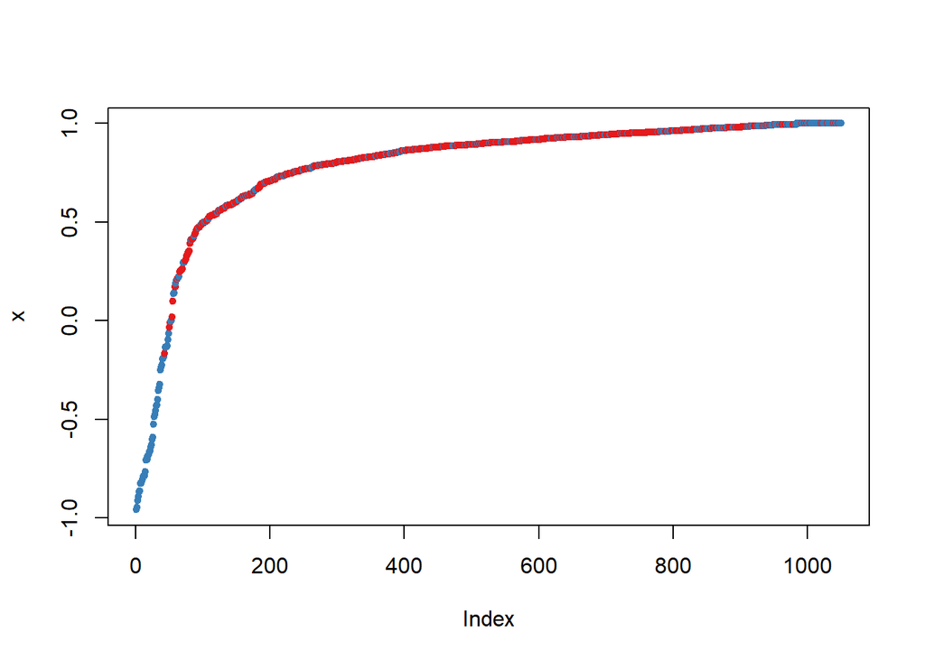

```r
plot(margin(rf.model,df_cc$Class))
```

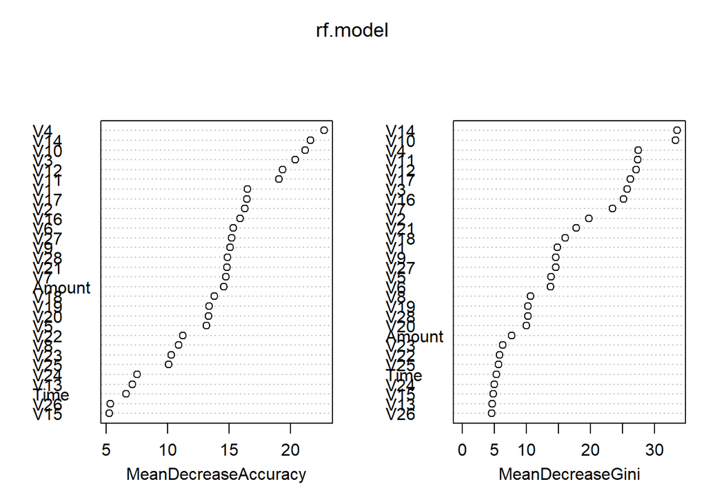

```r
varImpPlot(rf.model)
```

*ROC curve to find the area under the curve (AUC) for whole dataset*

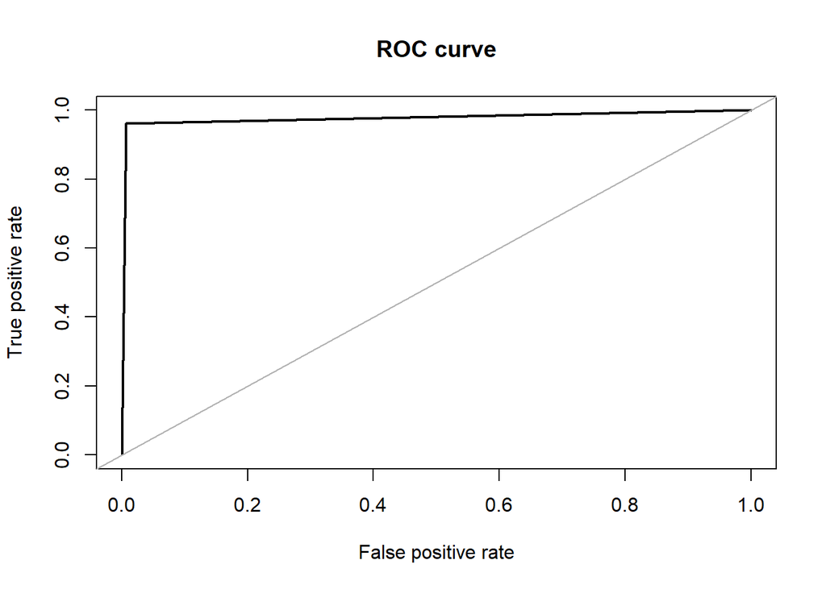

```
## Area under the curve (AUC): 0.977
```

```r
roc.curve(df_cc$Class, rf.pred.all, plotit = TRUE)
```

*The Random Forest is performing well to predict the False-negative so far. But, it also reported a number of genuine transactions under the fraudulent transaction that might impact the business in many ways. Since this dataset is PCA transformed, it’s almost impossible to trace which variables are causing this problem, or else it could have been an easy fix. Anyway, Random Forest is performing well on this dataset so far.*

# kNN

*Run the model with test dataset*

```r
set.seed(250)
knn.ctrl <- trainControl(method = "repeatedcv", repeats = 10, number = 5)
knn.model <- train(Class~., data = train, method = "knn",preProcess = c("center","scale"), trControl = knn.ctrl, tuneLength = 40)
knn.pred<- predict(knn.model, test[,-31])
knn.conf.matrix <- confusionMatrix(test$Class, knn.pred, mode = "everything", positive = "1")
knn.conf.matrix
```

```
## Confusion Matrix and Statistics
##
##           Reference
## Prediction   0   1
##          0 281   3
##          1  29 113
##
##                Accuracy : 0.9249
##                  95% CI : (0.8956, 0.9481)
##     No Information Rate : 0.7277
##     P-Value [Acc > NIR] : < 2.2e-16
##
##                   Kappa : 0.8229
##
##  Mcnemar's Test P-Value : 9.897e-06
##
##             Sensitivity : 0.9741
##             Specificity : 0.9065
##          Pos Pred Value : 0.7958
##          Neg Pred Value : 0.9894
##               Precision : 0.7958
##                  Recall : 0.9741
##                      F1 : 0.8760
##              Prevalence : 0.2723
##          Detection Rate : 0.2653
##    Detection Prevalence : 0.3333
##       Balanced Accuracy : 0.9403
##
##        'Positive' Class : 1
##
```

#### Plotting yields Number of Neighbours Vs accuracy (based on repeated cross validation)

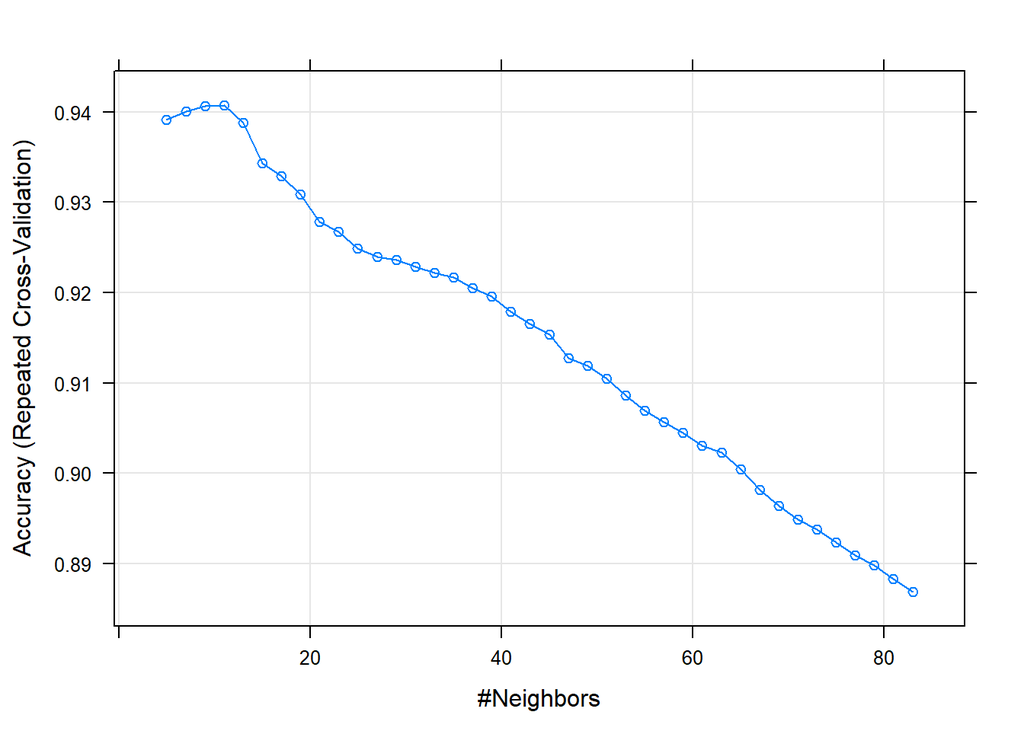

```r
plot(knn.model)
```

*ROC curve to find the area under the curve (AUC) for test dataset*

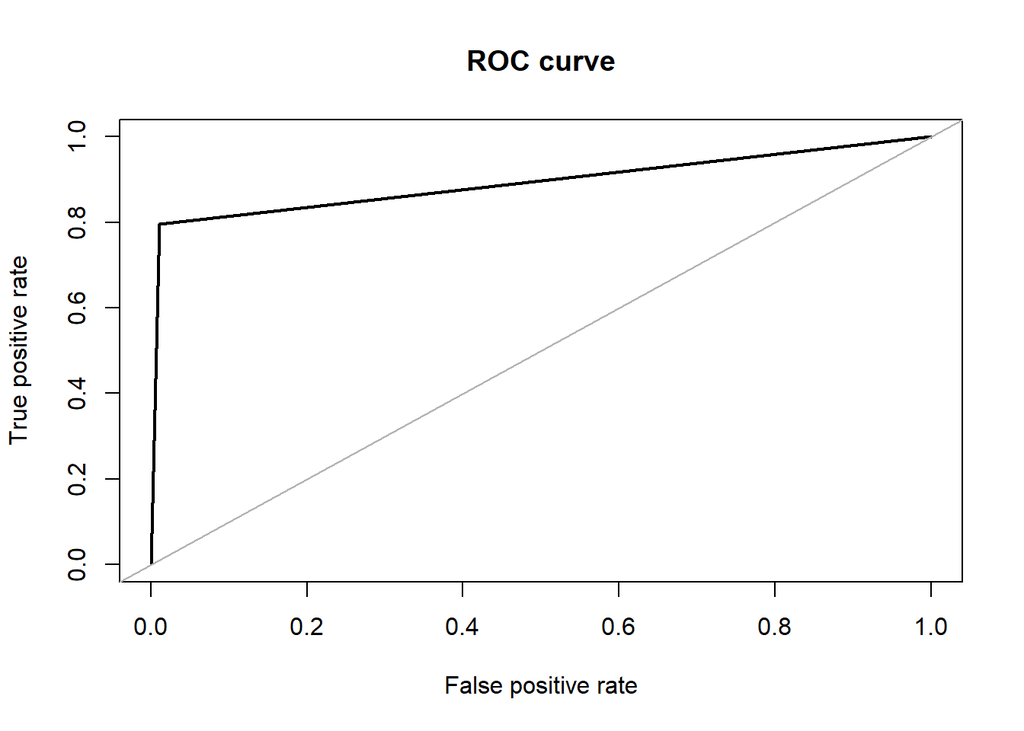

```
## Area under the curve (AUC): 0.893
```

```r
roc.curve(test$Class, knn.pred, plotit = TRUE)
```

*Run the model with whole dataset*

```r
knn.pred.all <- predict(knn.model, df_cc[,-31])
knn.conf.matrix.all <- confusionMatrix(df_cc$Class, knn.pred.all, mode = "everything", positive = "1")
knn.conf.matrix.all
```

```
## Confusion Matrix and Statistics
##
##           Reference
## Prediction      0      1
##          0 282497   1818
##          1     84    408
##
##                Accuracy : 0.9933
##                  95% CI : (0.993, 0.9936)
##     No Information Rate : 0.9922
##     P-Value [Acc > NIR] : 8.546e-13
##
##                   Kappa : 0.2982
##
##  Mcnemar's Test P-Value : < 2.2e-16
##
##             Sensitivity : 0.183288
##             Specificity : 0.999703
##          Pos Pred Value : 0.829268
##          Neg Pred Value : 0.993606
##               Precision : 0.829268
##                  Recall : 0.183288
##                      F1 : 0.300221
##              Prevalence : 0.007816
##          Detection Rate : 0.001433
##    Detection Prevalence : 0.001727
##       Balanced Accuracy : 0.591496
##
##        'Positive' Class : 1
##
```

*ROC curve to find the area under the curve (AUC) for whole dataset*

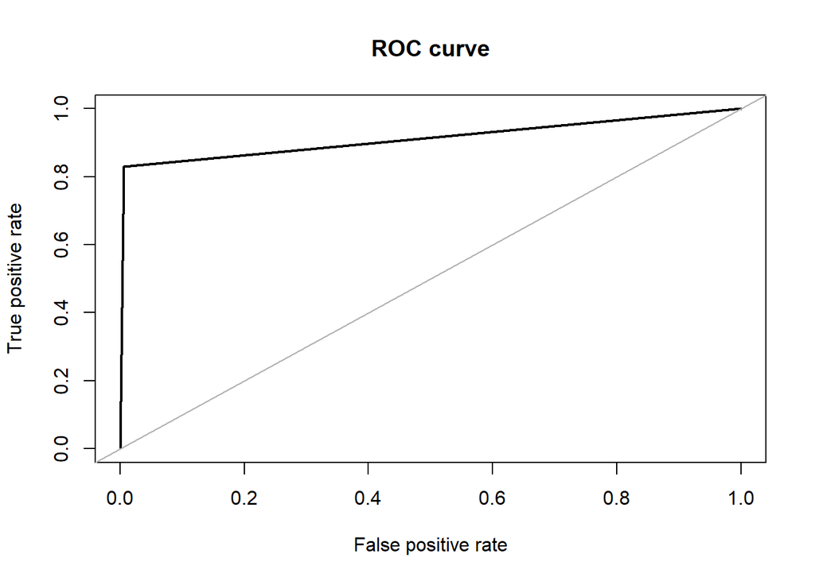

```
## Area under the curve (AUC): 0.911
```

```r
roc.curve(df_cc$Class, knn.pred.all, plotit = TRUE)
```

# Naive Bayes

*Run the model on test dataset*

```r
set.seed(123)
nb.iter.model <- naiveBayes(Class~., train, laplace = 1)
nb.iter.pred <- predict(nb.iter.model, test[,-31])
nb.conf.matrix <- confusionMatrix(test$Class, nb.iter.pred, mode = "everything", positive = "1")
nb.conf.matrix
```

```
## Confusion Matrix and Statistics
##
##           Reference
## Prediction   0   1
##          0 276   8
##          1  18 124
##
##                Accuracy : 0.939
##                  95% CI : (0.9118, 0.9597)
##     No Information Rate : 0.6901
##     P-Value [Acc > NIR] : < 2e-16
##
##                   Kappa : 0.8602
##
##  Mcnemar's Test P-Value : 0.07756
##
##             Sensitivity : 0.9394
##             Specificity : 0.9388
##          Pos Pred Value : 0.8732
##          Neg Pred Value : 0.9718
##               Precision : 0.8732
##                  Recall : 0.9394
##                      F1 : 0.9051
##              Prevalence : 0.3099
##          Detection Rate : 0.2911
##    Detection Prevalence : 0.3333
##       Balanced Accuracy : 0.9391
##
##        'Positive' Class : 1
##
```

*ROC curve to find the area under the curve (AUC) for test dataset*

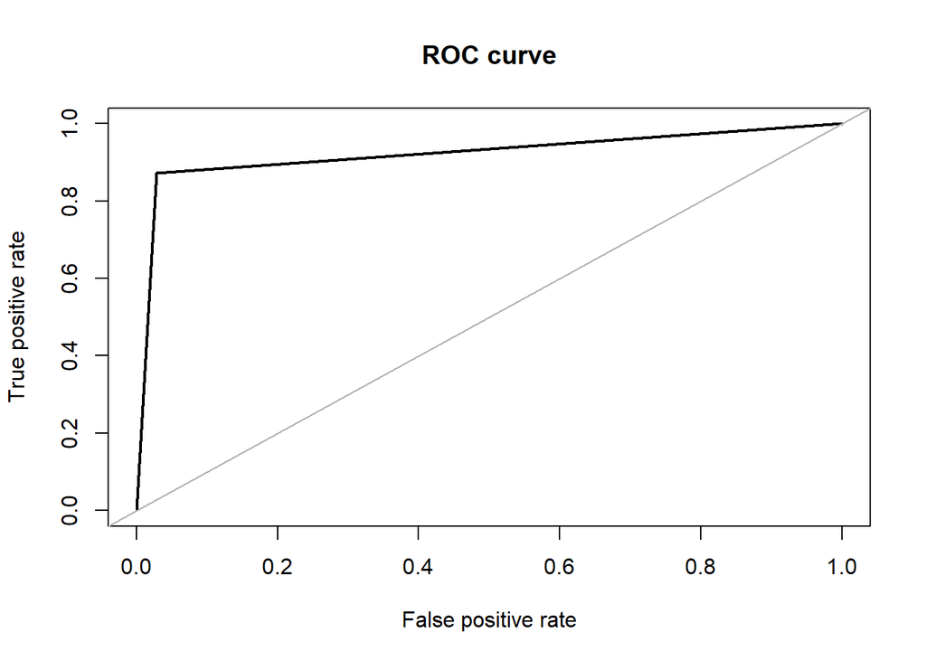

```
## Area under the curve (AUC): 0.923
```

```r
roc.curve(test$Class, nb.iter.pred, plotit = TRUE)
```

*Run the model on whole dataset*

```r
nb.iter.model.all <- naiveBayes(Class~., train, laplace = 1)
nb.iter.pred.all <- predict(nb.iter.model, df_cc[,-31])
nb.conf.matrix.all <- confusionMatrix(df_cc$Class, nb.iter.pred.all, mode = "everything", positive = "1")
nb.conf.matrix.all
```

```
## Confusion Matrix and Statistics
##
##           Reference
## Prediction      0      1
##          0 272390  11925
##          1     64    428
##
##                Accuracy : 0.9579
##                  95% CI : (0.9572, 0.9586)
##     No Information Rate : 0.9566
##     P-Value [Acc > NIR] : 0.0003921
##
##                   Kappa : 0.0635
##
##  Mcnemar's Test P-Value : < 2.2e-16
##
##             Sensitivity : 0.034647
##             Specificity : 0.999765
##          Pos Pred Value : 0.869919
##          Neg Pred Value : 0.958057
##               Precision : 0.869919
##                  Recall : 0.034647
##                      F1 : 0.066641
##              Prevalence : 0.043373
##          Detection Rate : 0.001503
##    Detection Prevalence : 0.001727
##       Balanced Accuracy : 0.517206
##
##        'Positive' Class : 1
##
```

*ROC curve to find the area under the curve (AUC) for whole dataset*

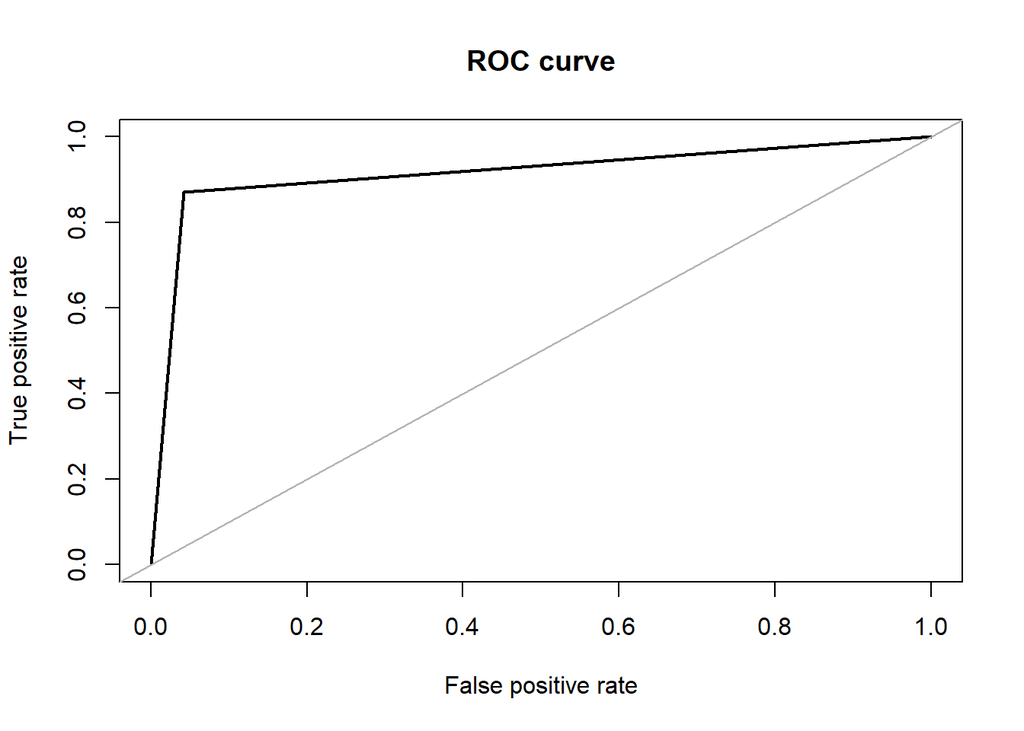

```
## Area under the curve (AUC): 0.914
```

```r
roc.curve(df_cc$Class, nb.iter.pred.all, plotit = TRUE)
```

# SVM Model

*Run the model on test dataset*

```r
set.seed(141)
gamma <- seq(0,0.1, len = 50)
cost <- 2^(-5:2)
svm.param<- expand.grid(cost=cost,gamma=gamma)
svm.conf.matrix <- NULL
smv.acc.list <- NULL

for(i in 1:nrow(svm.param)){
  smv.iret.model <- svm(Class~., data=train,
                        gamma=svm.param$gamma[i],cost=svm.param$cost[i])
  iter_pred_svm <- predict(smv.iret.model, test[,-31])
  svm.conf.matrix <- confusionMatrix(test$Class, iter_pred_svm, mode = "everything", positive = "1")
  smv.acc.list[i] <- svm.conf.matrix$overall[1]
}
```

```r
smv.acc.max <- max(smv.acc.list)
svm.expandgrid.index <- match(smv.acc.max,smv.acc.list)
svm.optimal.parameters <- svm.param[svm.expandgrid.index,]
svm.optimal.parameters
```

```
##    cost       gamma
## 24    4 0.004081633
```

*Run the model on test dataset*

```r
svm.model<- svm(Class~., data = train,
                 gamma=svm.optimal.parameters$gamma, cost = svm.optimal.parameters$cost)
svm.pred.model <- predict(svm.model, test[,-31])
svm.conf.matrix <- confusionMatrix(test$Class, svm.pred.model, mode = "everything", positive = "1")
svm.conf.matrix
```

```
## Confusion Matrix and Statistics
##
##           Reference
## Prediction   0   1
##          0 281   3
##          1  18 124
##
##                Accuracy : 0.9507
##                  95% CI : (0.9256, 0.9692)
##     No Information Rate : 0.7019
##     P-Value [Acc > NIR] : < 2e-16
##
##                   Kappa : 0.8861
##
##  Mcnemar's Test P-Value : 0.00225
##
##             Sensitivity : 0.9764
##             Specificity : 0.9398
##          Pos Pred Value : 0.8732
##          Neg Pred Value : 0.9894
##               Precision : 0.8732
##                  Recall : 0.9764
##                      F1 : 0.9219
##              Prevalence : 0.2981
##          Detection Rate : 0.2911
##    Detection Prevalence : 0.3333
##       Balanced Accuracy : 0.9581
##
##        'Positive' Class : 1
##
```

*ROC curve to find the area under the curve (AUC) for test dataset*

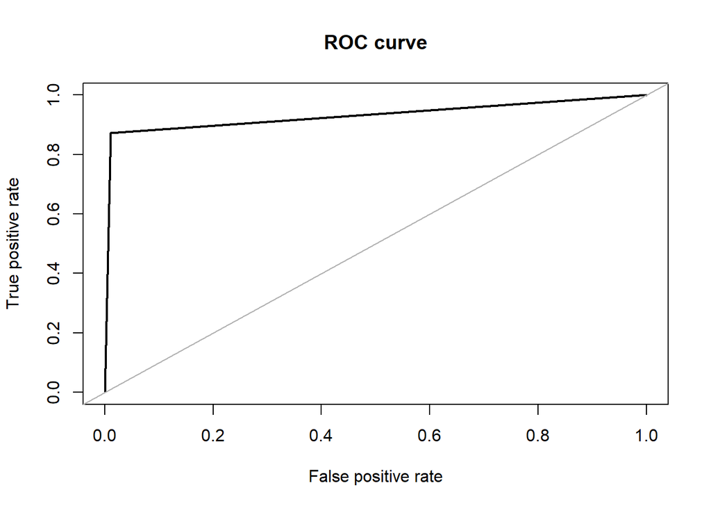

```
## Area under the curve (AUC): 0.931
```

```r
roc.curve(test$Class, svm.pred.model, plotit = TRUE)
```

*Run the model on whole dataset*

```r
svm.model.all<- svm(Class~., data = train,
                 gamma=svm.optimal.parameters$gamma, cost = svm.optimal.parameters$cost)
svm.pred.model.all <- predict(svm.model.all, df_cc[,-31])
svm.conf.matrix.all <- confusionMatrix(df_cc$Class, svm.pred.model.all, mode = "everything", positive = "1")
svm.conf.matrix.all
```

```
## Confusion Matrix and Statistics
##
##           Reference
## Prediction      0      1
##          0 282404   1911
##          1     63    429
##
##                Accuracy : 0.9931
##                  95% CI : (0.9928, 0.9934)
##     No Information Rate : 0.9918
##     P-Value [Acc > NIR] : 3.262e-15
##
##                   Kappa : 0.301
##
##  Mcnemar's Test P-Value : < 2.2e-16
##
##             Sensitivity : 0.183333
##             Specificity : 0.999777
##          Pos Pred Value : 0.871951
##          Neg Pred Value : 0.993279
##               Precision : 0.871951
##                  Recall : 0.183333
##                      F1 : 0.302966
##              Prevalence : 0.008216
##          Detection Rate : 0.001506
##    Detection Prevalence : 0.001727
##       Balanced Accuracy : 0.591555
##
##        'Positive' Class : 1
##
```

*ROC curve to find the area under the curve (AUC) for whole dataset*

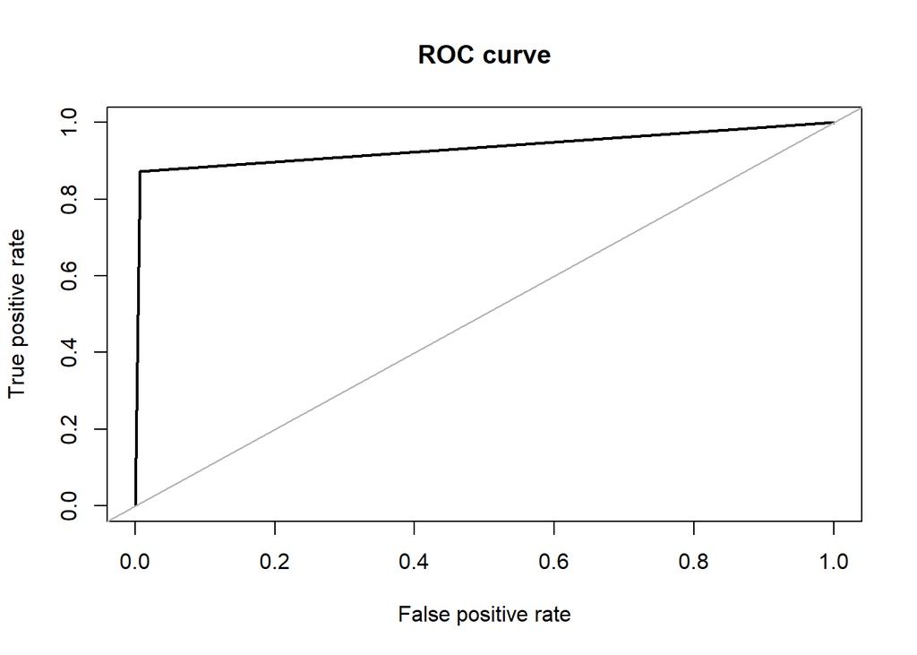

```
## Area under the curve (AUC): 0.933
```

```r
roc.curve(df_cc$Class, svm.pred.model.all, plotit = TRUE)
```

# Model Selection with FourFoldPlot

##### With whole dataset

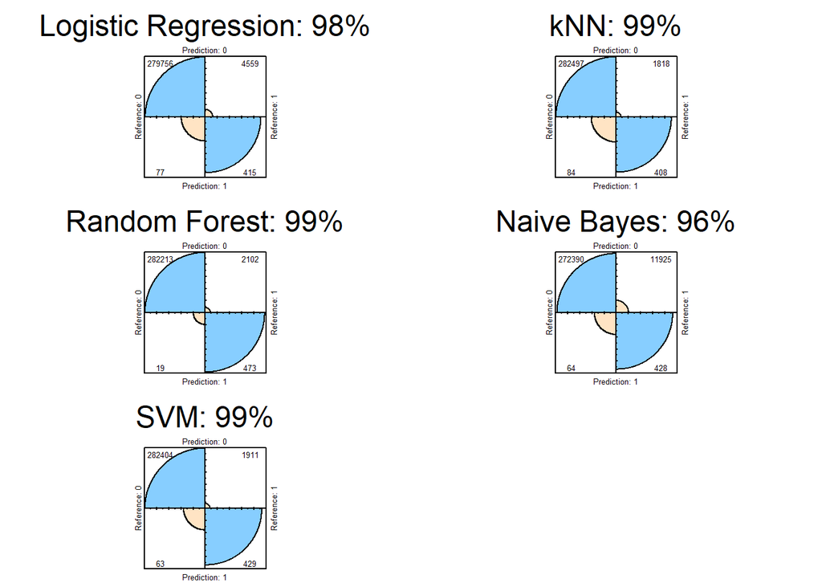

```r
col <- c("bisque", "skyblue1")
par(mfrow = c(3,2))
fourfoldplot(glm.fit.conf.matrix.all$table, color = col, conf.level = 0, margin = 1,
             main = paste("Logistic Regression: ",round(glm.fit.conf.matrix.all$overall[1]*100),"%",sep=""))

fourfoldplot(knn.conf.matrix.all$table, color = col, conf.level = 0, margin = 1,
             main = paste("kNN: ",round(knn.conf.matrix.all$overall[1]*100),"%",sep=""))

fourfoldplot(rf.conf.matrix.all$table, color = col, conf.level = 0, margin = 1,
             main = paste("Random Forest: ",round(rf.conf.matrix.all$overall[1]*100),"%",sep=""))

fourfoldplot(nb.conf.matrix.all$table, color = col, conf.level = 0, margin = 1,
             main = paste("Naive Bayes: ",round(nb.conf.matrix.all$overall[1]*100),"%",sep=""))

fourfoldplot(svm.conf.matrix.all$table, color = col, conf.level = 0, margin = 1,
             main = paste("SVM: ",round(svm.conf.matrix.all$overall[1]*100),"%",sep=""))
```

##### With Test Dataset

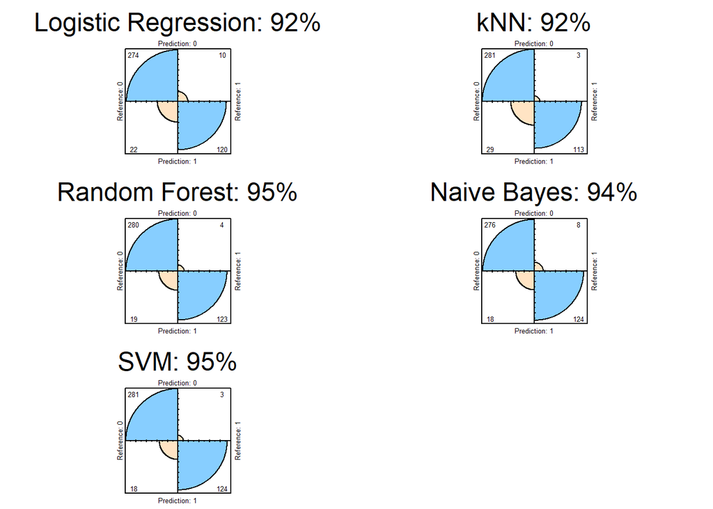

```r
col <- c("bisque", "skyblue1")
par(mfrow = c(3,2))
fourfoldplot(glm.fit.conf.matrix$table, color = col, conf.level = 0, margin = 1,
             main = paste("Logistic Regression: ",round(glm.fit.conf.matrix$overall[1]*100),"%",sep=""))

fourfoldplot(knn.conf.matrix$table, color = col, conf.level = 0, margin = 1,
             main = paste("kNN: ",round(knn.conf.matrix$overall[1]*100),"%",sep=""))

fourfoldplot(rf.conf.matrix$table, color = col, conf.level = 0, margin = 1,
             main = paste("Random Forest: ",round(rf.conf.matrix$overall[1]*100),"%",sep=""))

fourfoldplot(nb.conf.matrix$table, color = col, conf.level = 0, margin = 1,
             main = paste("Naive Bayes: ",round(nb.conf.matrix$overall[1]*100),"%",sep=""))

fourfoldplot(svm.conf.matrix$table, color = col, conf.level = 0, margin = 1,
             main = paste("SVM: ",round(svm.conf.matrix$overall[1]*100),"%",sep=""))
```

#### The fourfold plots above shows that the SVM and Random Forest are performing well.

#### For the final predictions, let’s combined the GLM, Random Forest, KNN, Naive Bayes, SVM and calculate the overall, fraudulent, and genuine transactions’ accuracy.

```r
models.combined <- (as.integer(knn.pred.all) + as.integer(rf.pred.all) + as.integer(nb.iter.pred.all) + as.integer(glm.fit.pred.all) + as.integer(svm.pred.model.all) - 5)/5
models.combined <- as.data.table(models.combined)
pred.final <- ifelse(models.combined > 0.75, 1, 0)
table.final <- table(actual = df_cc$Class, predicted = pred.final)
table.final
```

```
##       predicted
## actual      0      1
##      0 283420    895
##      1     74    418
```

##### The accuracy for overall, fraud, and genuin as follows:

```r
accuracy <- (table.final[1,1] + table.final[2,2])/(nrow(df_cc))*100
table.class <- table(df_cc$Class)
fraud.accuracy <- table.final[2,2]/table.class[2]*100
genuin.accuracy <- table.final[1,1]/table.class[1]*100
```

```r
# Overall Accuracy:
accuracy
```

```
## [1] 99.65977
```

```r
# Fraud Detection Accuracy:
fraud.accuracy
```

```
##        1
## 84.95935
```

```r
# Genuine Transaction Detection Accuracy:
genuin.accuracy
```

```
##        0
## 99.68521
```

# Conclusions

#### After all this EDA, Model Building, and Analysis, it seems either SVM and or Random Forest would be the best option if the intention is to detect fraudulent transactions only. However, the combined average of GLM, Random Forest, KNN, Naive Bayes, and SVM could also provide a good fit with the balance of the fraudulent and genuine class.